# 2 Flexible parametric survival

## 1 Learning objectives

**Note**

By the end of this lecture, you should be able to:

- Apply understanding of **flexible parametric survival models** and **competing risks approaches**
- Use **cause-specific approach** to fit flexible parametric survival models
- Interpret **transition-specific hazard ratios** for covariate effects

## 2 Flexible parametric & competing risks

We have learnt about flexible parametric survival models and competing risks approach. Let’s now apply competing risks approach, similar to what we have learnt from fitting cause-specific Cox models, to flexible parametric survival models.

## 3 Worked example

### 3.1 Data set up

**Show R code**

```r
#load libraries
library(readr)
library(mstate)
library(dplyr)
library(tidyverse)
library(flexsurv)

#Read in data
cvd_death <- read_csv("https://raw.githubusercontent.com/NicoleDeLaMata/AdvancedSurvival/refs/heads/Data/cvd_death.csv")

#Tablulate events
table(cvd_death$state)
```

```
  0   2   3
443 212  95
```

### 3.2 msprep data

Let’s now run our data through `msprep` from the mstate package. We need to define our transition matrix and we will subsequently see how our data creates new observation rows for each individual, censoring for the other possible outcome that wasn’t observed and creating a `trans` variable.

**Show R code**

```r
#Transition matrix - 2 death outcomes
tmat <- transMat(x = list(c(2,3), c(), c()), names=c("Alive", "CVD death", "Other death"))
tmat
```

```
             to
from          Alive CVD death Other death
  Alive          NA         1           2
  CVD death      NA        NA          NA
  Other death    NA        NA          NA
```

**Show R code**

```r
#Minor adjustments to data prep
cvd_death <- cvd_death %>%
  mutate(time = case_when(
        time<=time0 ~ time0+0.01,
        time>time0 ~ time
  ),
         time_cvdd=time,
         time_othd=time,
         status_cvdd=case_when(
         state==2 & status==1 ~ 1,
         TRUE ~ 0
         ),
         status_othd=case_when(
         state==3 & status==1 ~ 1,
         TRUE ~ 0
         ),
         )

#Reshape using msprep
cvd_death_msp <- msprep(data=cvd_death, trans=tmat, time=c(NA, "time_cvdd", "time_othd"), status=c(NA, "status_cvdd", "status_othd"), keep=c("age", "cvd", "diab", "malesex", "ses", "trt"))
```

### 3.3 Fit flexsurvspline

Our data has been prepared in a way that makes it easier for us to fit specific models for each competing event, calling upon the `trans` variable. Below we have fitted 1 internal knots.

**Show R code**

```r
#Model factor variables
cvd_death_msp$ses <- as.factor(cvd_death_msp$ses)

#Age to per 10 years
cvd_death_msp$age10 <- cvd_death_msp$age/10 #in decades

#Fit separate models for each cause of death
fs_cvdd <- flexsurvspline(Surv(Tstart, Tstop, status) ~ age10 + cvd + diab + malesex + ses + trt, data=cvd_death_msp, subset=(trans==1), k=1, scale="hazard")
fs_cvdd
```

```
Call:
flexsurvspline(formula = Surv(Tstart, Tstop, status) ~ age10 +
    cvd + diab + malesex + ses + trt, data = cvd_death_msp, subset = (trans ==
    1), k = 1, scale = "hazard")

Estimates:
         data mean  est      L95%     U95%     se       exp(est)  L95%
gamma0        NA    -4.5331  -5.4737  -3.5926   0.4799       NA        NA
gamma1        NA     2.0970   1.5104   2.6836   0.2993       NA        NA
gamma2        NA     0.0447  -0.0294   0.1187   0.0378       NA        NA
age10     5.4257     0.1697   0.0530   0.2865   0.0596   1.1850    1.0544
cvd       0.5120     1.6280   1.1551   2.1010   0.2413   5.0939    3.1742
diab      0.5640     0.4441   0.0825   0.8057   0.1845   1.5590    1.0860
malesex   0.5813     0.2822  -0.0305   0.5948   0.1595   1.3260    0.9700
ses2      0.2000     0.2323  -0.2544   0.7189   0.2483   1.2615    0.7754
ses3      0.2387    -0.0437  -0.5259   0.4386   0.2460   0.9573    0.5910
ses4      0.3373     0.1080  -0.3416   0.5577   0.2294   1.1141    0.7106
trt       0.6027    -0.2833  -0.5929   0.0264   0.1580   0.7533    0.5527
         U95%
gamma0        NA
gamma1        NA
gamma2        NA
age10     1.3318
cvd       8.1746
diab      2.2382
malesex   1.8127
ses2      2.0522
ses3      1.5505
ses4      1.7467
trt       1.0267

N = 750,  Events: 212,  Censored: 538
Total time at risk: 939.2144
Log-likelihood = -389.756, df = 11
AIC = 801.5121
```

**Show R code**

```r
fs_othd <- flexsurvspline(Surv(Tstart, Tstop, status) ~ age10 + cvd + diab + malesex + ses + trt, data=cvd_death_msp, subset=(trans==2), k=1, scale="hazard")
fs_othd
```

```
Call:
flexsurvspline(formula = Surv(Tstart, Tstop, status) ~ age10 +
    cvd + diab + malesex + ses + trt, data = cvd_death_msp, subset = (trans ==
    2), k = 1, scale = "hazard")

Estimates:
         data mean  est       L95%      U95%      se        exp(est)  L95%
gamma0         NA   -10.6494  -12.7719   -8.5270    1.0829        NA        NA
gamma1         NA     1.2414    0.5476    1.9351    0.3540        NA        NA
gamma2         NA    -0.0249   -0.0920    0.0422    0.0342        NA        NA
age10      5.4257     1.1208    0.8964    1.3452    0.1145    3.0673    2.4509
cvd        0.5120    -1.1678   -1.6176   -0.7180    0.2295    0.3111    0.1984
diab       0.5640     0.0931   -0.4858    0.6720    0.2954    1.0976    0.6152
malesex    0.5813    -0.1697   -0.5987    0.2594    0.2189    0.8439    0.5495
ses2       0.2000     0.7454   -0.3862    1.8769    0.5773    2.1072    0.6797
ses3       0.2387     1.3262    0.2789    2.3735    0.5344    3.7668    1.3217
ses4       0.3373     0.9098   -0.1366    1.9563    0.5339    2.4839    0.8723
trt        0.6027    -0.0854   -0.5350    0.3641    0.2294    0.9181    0.5857
         U95%
gamma0         NA
gamma1         NA
gamma2         NA
age10      3.8388
cvd        0.4877
diab       1.9582
malesex    1.2962
ses2       6.5333
ses3      10.7354
ses4       7.0728
trt        1.4393

N = 750,  Events: 95,  Censored: 655
Total time at risk: 939.2144
Log-likelihood = -197.1684, df = 11
AIC = 416.3368
```

We can see the covariates effects differ between those relating to CVD deaths and other deaths. Associated with CVD deaths, we see older age (per 10 years) increases risk of cardiovascular death by nearly 20% (HR: 1.19, 95%CI: 1.05, 1.33), cardiovascular comorbidity by 5 times (HR: 5.09, 95%CI: 3.17, 8.17) and diabetes comorbidity by approximately 50% (HR: 1.56, 95%CI: 1.09, 2.24).

### 3.4 Binding models

Since we have two models, one for each cause of death (CVD death and other death), we can bind these two models together. The benefit of this is being able use functions to produce estimates for each outcome, such as cumulative incidence.

**Show R code**

```r
#Define matrix for each transition
tmat_fsurv <- rbind(c(NA,1,2), c(NA, NA, NA), c(NA, NA, NA))
tmat_fsurv
```

```
     [,1] [,2] [,3]
[1,]   NA    1    2
[2,]   NA   NA   NA
[3,]   NA   NA   NA
```

**Show R code**

```r
#Group models together
fsurv_2dth <- fmsm(fs_cvdd, fs_othd, trans=tmat_fsurv)
fsurv_2dth
```

```
State 1 - State 2
flexsurvspline(formula = Surv(Tstart, Tstop, status) ~ age10 +
    cvd + diab + malesex + ses + trt, data = cvd_death_msp, subset = (trans ==
    1), k = 1, scale = "hazard")

State 1 - State 3
flexsurvspline(formula = Surv(Tstart, Tstop, status) ~ age10 +
    cvd + diab + malesex + ses + trt, data = cvd_death_msp, subset = (trans ==
    2), k = 1, scale = "hazard")
```

**Show R code**

```r
#AIC for entire model
AIC(fs_cvdd)+AIC(fs_othd)
```

```
[1] 1217.849
```

**Show R code**

```r
AIC(fsurv_2dth)
```

```
[1] 1217.849
```

### 3.5 Cumulative hazard

Let’s use our models to produce the cumulative hazard. This can be for the reference levels of the covariates (i.e. no covariate effects) or for certain covariate patterns. We will look at the difference between those with cardiovascular comorbidity, and its relation to cardiovascular deaths and other deaths.

**Show R code**

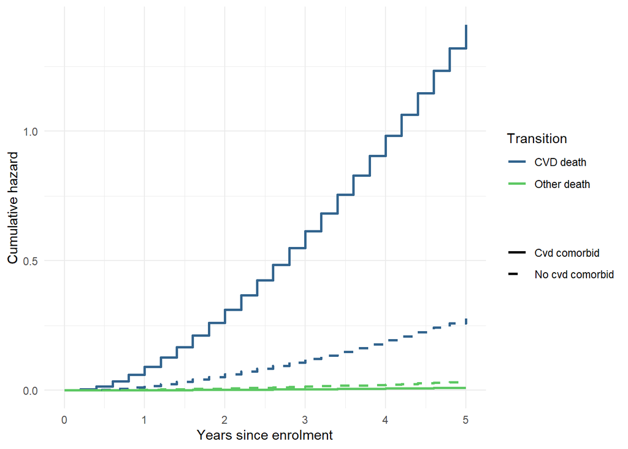

```r
#New data to estimate on - ref level
preddata0 <- data.frame(
  trt = c(0),
  age10=c(4),
  cvd=c(0),
  diab=c(0),
  malesex=c(0),
  ses = c("1"))

#Cumulative intensity function
cum_haz0<- msfit.flexsurvreg(fsurv_2dth, t=seq(0,5,by=0.2), newdata=preddata0, trans=tmat_fsurv)

#New data to estimate on - cvd comorbidity
preddata1 <- data.frame(
  trt = c(0),
  age10=c(4),
  cvd=c(1),
  diab=c(0),
  malesex=c(0),
  ses = c("1"))

#Cumulative intensity function - cvd comorbidity
cum_haz1<- msfit.flexsurvreg(fsurv_2dth, t=seq(0,5,by=0.2), newdata=preddata1, trans=tmat_fsurv)

#Store data into one
ct1 <- cum_haz0$Haz %>% mutate(model = "No cvd comorbid")
ct2 <- cum_haz1$Haz %>% mutate(model = "Cvd comorbid")

ct_all <- bind_rows(ct1, ct2)
ct_all <- ct_all %>%
  mutate(trans2 = case_when(
    trans==1 ~ "CVD death",
    trans==2 ~ "Other death"  ))

#Graph settings
mycolor <- c("#440154FF","#32648EFF","#21908CFF","#5DC863FF","#DCE318FF","#FFFFFF")

#Plot - stepped
#| fig-width: 2
#| fig-height: 3
ggplot(ct_all,
       aes(x = time,
           y = Haz,
           colour = factor(trans2),
           linetype = model,
           group = interaction(trans2, model))) +
  geom_step(size = 1) +
  scale_colour_manual(values = mycolor[c(2,4, 1)],
                      name = "Transition") +
  scale_linetype_manual(values = c("solid", "dashed"),
                        name = " ") +
  labs(x = "Years since enrolment", y = "Cumulative hazard") +
  theme_minimal()
```

**Show R code**

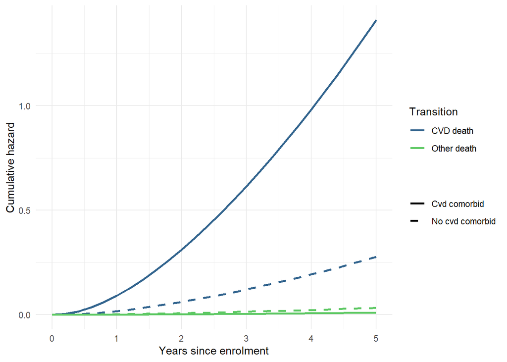

```r
#Plot - smoothed line
#| fig-width: 2
#| fig-height: 3
ggplot(ct_all,
       aes(x = time,
           y = Haz,
           colour = factor(trans2),
           linetype = model,
           group = interaction(trans2, model))) +
  geom_line(size = 1) +
  scale_colour_manual(values = mycolor[c(2,4, 1)],
                      name = "Transition") +
  scale_linetype_manual(values = c("solid", "dashed"),
                        name = " ") +
  labs(x = "Years since enrolment", y = "Cumulative hazard") +
  theme_minimal()
```

As expected, the pattern of the cumulative hazard is similar to the interpretation of the covariates. The cardiovascular comorbidity greatly increases the risk of cardiovascular death, but not so much other death. We also see the cumulative hazard of cardiovascular death is much greater than other deaths.

### 3.6 Transition probability

Let’s now look at the probability of having CVD death and other death, compared to being alive over follow-up time. You will need to call upon an object from `msfit`, so those specifications will carry onto the probability estimates.

**Show R code**

```r
#Probabilities in state - ref level
pr0 <- probtrans(cum_haz0, predt = 0)
pr0[[1]]
```

```
   time   pstate1      pstate2      pstate3          se1          se2
1   0.0 1.0000000 0.0000000000 0.0000000000 0.0000000000 0.0000000000
2   0.2 0.9989827 0.0007225594 0.0002947603 0.0005788817 0.0004507062
3   0.4 0.9962659 0.0029936629 0.0007404068 0.0015611405 0.0013245713
4   0.6 0.9920129 0.0066923148 0.0012948163 0.0029717598 0.0026237478
5   0.8 0.9864149 0.0116402211 0.0019448765 0.0048133088 0.0043553360
6   1.0 0.9796493 0.0176678790 0.0026827947 0.0070472048 0.0064795258
7   1.2 0.9718739 0.0246231727 0.0035029566 0.0096172188 0.0089382595
8   1.4 0.9632277 0.0323715556 0.0044007784 0.0124670287 0.0116738538
9   1.6 0.9538291 0.0407997549 0.0053711394 0.0155495805 0.0146386036
10  1.8 0.9437652 0.0498262734 0.0064085648 0.0188329559 0.0178008924
11  2.0 0.9331065 0.0593855509 0.0075079458 0.0222941408 0.0211383054
12  2.2 0.9219141 0.0694214545 0.0086644824 0.0259150737 0.0246334892
13  2.4 0.9102413 0.0798850398 0.0098736354 0.0296806507 0.0282721247
14  2.6 0.8981359 0.0907329712 0.0111310913 0.0335774285 0.0320416120
```

[output cut: 39 more lines]

**Show R code**

```r
#Probabilities in state - cvd comorbidity
pr1 <- probtrans(cum_haz1, predt = 0)
pr1[[1]]
```

```
   time   pstate1     pstate2      pstate3         se1         se2          se3
1   0.0 1.0000000 0.000000000 0.000000e+00 0.000000000 0.000000000 0.0000000000
2   0.2 0.9962276 0.003680665 9.168684e-05 0.002114212 0.002109180 0.0001025110
3   0.4 0.9845525 0.015217597 2.299254e-04 0.005894640 0.005883694 0.0002264598
4   0.6 0.9657629 0.033836747 4.003500e-04 0.011274357 0.011257828 0.0003781690
5   0.8 0.9410287 0.058374085 5.972042e-04 0.018158114 0.018136751 0.0005498925
6   1.0 0.9115180 0.087665788 8.161767e-04 0.026195239 0.026169854 0.0007357062
7   1.2 0.8783149 0.120631532 1.053550e-03 0.034953670 0.034925250 0.0009310167
8   1.4 0.8423924 0.156301622 1.305938e-03 0.044028724 0.043998543 0.0011321921
9   1.6 0.8045817 0.193848436 1.569909e-03 0.053093420 0.053063097 0.0013362119
10  1.8 0.7655237 0.232634222 1.842113e-03 0.061918185 0.061889715 0.0015404994
11  2.0 0.7257485 0.272131988 2.119497e-03 0.070335597 0.070311305 0.0017428744
12  2.2 0.6857071 0.311893620 2.399300e-03 0.078219718 0.078202190 0.0019414868
13  2.4 0.6457830 0.351537987 2.679048e-03 0.085475335 0.085467348 0.0021347773
14  2.6 0.6063015 0.390741930 2.956547e-03 0.092030987 0.092035432 0.0023214509
15  2.8 0.5675370 0.429233147 3.229871e-03 0.097834479 0.097854292 0.0025004572
16  3.0 0.5297183 0.466784387 3.497354e-03 0.102849969 0.102888062 0.0026709735
17  3.2 0.4930339 0.503208533 3.757578e-03 0.107056007 0.107115206 0.0028323876
18  3.4 0.4576363 0.538354344 4.009356e-03 0.110444101 0.110527092 0.0029842807
19  3.6 0.4236456 0.572102668 4.251721e-03 0.113017567 0.113126845 0.0031264103
20  3.8 0.3911531 0.604363026 4.483907e-03 0.114790469 0.114928300 0.0032586913
21  4.0 0.3602242 0.635070490 4.705337e-03 0.115786582 0.115954968 0.0033811773
22  4.2 0.3309016 0.664182804 4.915600e-03 0.116038324 0.116238977 0.0034940419
23  4.4 0.3032078 0.691677715 5.114442e-03 0.115585627 0.115819958 0.0035975597
24  4.6 0.2771478 0.717550497 5.301746e-03 0.114474787 0.114743891 0.0036920880
25  4.8 0.2527108 0.741811649 5.477516e-03 0.112757267 0.113061928 0.0037780492
26  5.0 0.2298734 0.764484751 5.641861e-03 0.110488511 0.110829208 0.0038559145
```

**Show R code**

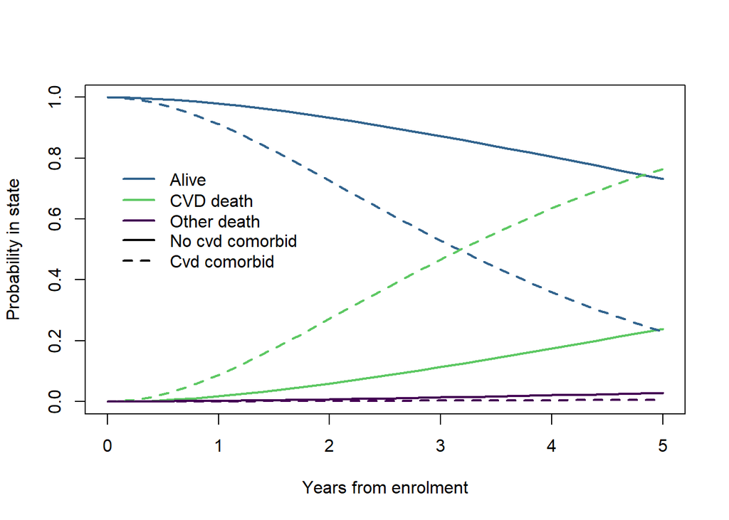

```r
#Store data into one
pr_none <- pr0[[1]] %>% mutate(model = "No cvd comorbid")
pr_cvd <- pr1[[1]] %>% mutate(model = "Cvd comorbid")

#Plot of probabilities in state
#| fig-width: 2
#| fig-height: 3
matplot(pr_none$time,
        pr_none[, grep("^pstate", names(pr_none))],
        type = "l",
        lwd  = 2,
        lty  = 1,
        xlab = "Years from enrolment",
        ylab = "Probability in state",
        col  = mycolor[c(2,4, 1)])

matlines(pr_cvd$time,
         pr_cvd[, grep("^pstate", names(pr_cvd))],
         type = "l",
         lwd  = 2,
         lty  = 2,
         col  = mycolor[c(2,4, 1)])

# legend for states (colours)
legend(0, 0.8,
       legend = c("Alive", "CVD death", "Other death"),
       col    = mycolor[c(2,4, 1)],
       lty    = 1,
       lwd    = 2,
       bty    = "n")

# legend for models (linetypes)
legend(0,0.6,
       legend = c("No cvd comorbid", "Cvd comorbid"),
       lty    = c(1, 2),
       lwd    = 2,
       col    = "black",
       bty    = "n")
```

## 4 Data exercise

You have been provided with a [new dataset](https://github.com/NicoleDeLaMata/AdvancedSurvival/blob/Data/competing_2deaths.csv) including the following variables. Use the [coding template](https://github.com/NicoleDeLaMata/AdvancedSurvival/blob/Coding/competingrisk_flexsurv_exercise.R) to undertake similar datasteps and analysis above to produce:

- Flexible parametric survival model with 1 internal knot for two causes of death (cardiovascular vs other deaths)
- Cumulative hazards plot
- Probability of each cause of death plot

Please refer to the solutions here and R coding here (uploaded following workshop).